# Risk ratios

Author

Alexander W. Gofton & Emily Smith

Published

March 13, 2026

## Setup

Load packages for epidemiological risk ratio calculations, model tidying, data manipulation, and plot composition.

```r
library(epitools)
library(broom)
library(tidyverse)
library(patchwork)
```

## Plot Theme

Configure the global ggplot theme for risk ratio forest plots.

```r
theme_set(
  theme_classic() +
    theme(
      axis.text.x = element_text(size = 11, angle = 45, hjust = 1),
      axis.title.x = element_text(size = 12),
      axis.text.y = element_text(size = 11),
      axis.title.y = element_text(size = 12),
      axis.line = element_line(colour = "grey70"),
      axis.ticks = element_line(colour = "grey70"),
      text = element_text(family = "Arial"),
      panel.grid.major.x = element_line(linewidth = 0.1, colour = "grey70"),
      panel.grid.minor.x = element_line(linewidth = 0.05, colour = "grey70")
    )
)
```

# Load Data

Import the preprocessed datasets with age categories for both deduplicated and full (with repeat tests) datasets.

```r
data_no_multi <- read_csv("data/preprocessed_no_multi_with_age_cat.csv")
data_with_multi <- read_csv("data/preprocessed_with_multi_with_age_cat.csv")
```

# Cross-Tabulation: Age by Sex

Create a summary table of positive and negative test counts by age category and sex, with derived metrics including male-to-female ratios and positivity percentages.

```r
age_by_sex_data <- data_no_multi %>%
  count(Age_cat, Sex, Status) %>%
  pivot_wider(names_from = c(Status, Sex), values_from = n, values_fill = 0) %>%
  mutate(
    Total = Negative_F + Positive_F + Negative_M + Positive_M,
    Total_F = Negative_F + Positive_F,
    Total_M = Negative_M + Positive_M, # Fixed: was Negative_M + Negative_M
    MF_ratio = Total_M / Total_F,
    Positive = Positive_F + Positive_M,
    Positive_pct = (Positive / Total) * 100,
    Positive_F_pct = (Positive_F / (Positive_F + Negative_F)) * 100,
    Positive_M_pct = (Positive_M / (Positive_M + Negative_M)) * 100
  )

write_csv(age_by_sex_data, "results/age_by_sex_data.csv")
```

## Age by Sex (All Tests)

Repeat the age-sex cross-tabulation using the full dataset including repeat tests.

```r
# age_by_sex for number of tests (with multi)
age_by_sex_data_multi <- data_with_multi %>%
  count(Age_cat, Sex, Status) %>%
  pivot_wider(names_from = c(Status, Sex), values_from = n, values_fill = 0) %>%
  mutate(
    Total = Negative_F + Positive_F + Negative_M + Positive_M,
    Total_F = Negative_F + Positive_F,
    Total_M = Negative_M + Positive_M, # Fixed: was Negative_M + Negative_M
    MF_ratio = Total_M / Total_F,
    Positive = Positive_F + Positive_M,
    Positive_pct = (Positive / Total) * 100,
    Positive_F_pct = (Positive_F / (Positive_F + Negative_F)) * 100,
    Positive_M_pct = (Positive_M / (Positive_M + Negative_M)) * 100
  )

write_csv(age_by_sex_data_multi, "results/age_by_sex_with_multi_data.csv")
```

# Risk Ratio: Females vs Males (Overall)

Calculate the overall risk ratio comparing alpha-gal positivity between females and males across all age groups using a 2x2 contingency table and Fisher’s exact test.

```r
# Calculate overall RR for females vs males (whole dataset)
overall_sex_summary <- data_no_multi |>
  count(Sex, Status) |>
  pivot_wider(names_from = Status, values_from = n, values_fill = 0)

# Extract counts
pos_M <- overall_sex_summary$Positive[overall_sex_summary$Sex == "M"]
neg_M <- overall_sex_summary$Negative[overall_sex_summary$Sex == "M"]
pos_F <- overall_sex_summary$Positive[overall_sex_summary$Sex == "F"]
neg_F <- overall_sex_summary$Negative[overall_sex_summary$Sex == "F"]

# Create 2x2 matrix: rows = sex, cols = positive/negative
overall_rr_mat <- matrix(
  c(pos_M, neg_M, pos_F, neg_F),
  nrow = 2,
  byrow = TRUE,
  dimnames = list(
    Sex = c("Male", "Female"),
    Status = c("Positive", "Negative")
  )
)

# Corrected overall sex RR with columns reversed
overall_sex_rr <- riskratio(overall_rr_mat, rev = "columns")

# Extract Row 2 (Female compared to Male)
overall_rr_results <- tibble(
  Comparison = "Female vs Male",
  RR = overall_sex_rr$measure[2, "estimate"],
  Lower_CI = overall_sex_rr$measure[2, "lower"],
  Upper_CI = overall_sex_rr$measure[2, "upper"],
  P_value = overall_sex_rr$p.value[2, "fisher.exact"]
)

print(overall_rr_results)

# If you want Male vs Female instead, calculate reciprocal
overall_rr_results_male <- tibble(
  Comparison = "Male vs Female",
  RR = 1 / overall_sex_rr$measure[2, "estimate"],
  Lower_CI = 1 / overall_sex_rr$measure[2, "upper"],  # Note: swap upper/lower
  Upper_CI = 1 / overall_sex_rr$measure[2, "lower"],
  P_value = overall_sex_rr$p.value[2, "fisher.exact"]
)

print(overall_rr_results_male)
```

```
# A tibble: 1 × 5
  Comparison        RR Lower_CI Upper_CI  P_value
  <chr>          <dbl>    <dbl>    <dbl>    <dbl>
1 Female vs Male 0.770    0.737    0.805 6.64e-30
# A tibble: 1 × 5
  Comparison        RR Lower_CI Upper_CI  P_value
  <chr>          <dbl>    <dbl>    <dbl>    <dbl>
1 Male vs Female  1.30     1.24     1.36 6.64e-30
```

# Risk Ratio: Females vs Males by Age Category

```r
calc_rr <- function(df, age_cat) {
  rr_df <- df |>
    filter(Age_cat == age_cat)

  posM <- rr_df$Positive_M
  negM <- rr_df$Total_M - rr_df$Positive_M
  posF <- rr_df$Positive_F
  negF <- rr_df$Total_F - rr_df$Positive_F

  # Correct 2x2 matrix structure
  # Rows = exposure (sex), Columns = outcome (positive, negative)
  rr_mat <- matrix(
    c(posM, negM, posF, negF),
    nrow = 2,
    byrow = TRUE,
    dimnames = list(
      Sex = c("Male", "Female"),
      Status = c("Positive", "Negative")
    )
  )

  rr <- riskratio(rr_mat)

  tibble(
    Age_cat = age_cat,
    RR = rr$measure[2, "estimate"],
    Lower_CI = rr$measure[2, "lower"],
    Upper_CI = rr$measure[2, "upper"],
    P_value = rr$p.value[2, "fisher.exact"]
  )
}
```

```r
rr_0 <- calc_rr(age_by_sex_data, "0-14") #%>% mutate(Age_cat = "0-14")
rr_15 <- calc_rr(age_by_sex_data, "15-24") #%>% mutate(Age_cat = "15-24")
rr_25 <- calc_rr(age_by_sex_data, "25-34") #%>% mutate(Age_cat = "25-34")
rr_35 <- calc_rr(age_by_sex_data, "35-44") #%>% mutate(Age_cat = "35-44")
rr_45 <- calc_rr(age_by_sex_data, "45-54") #%>% mutate(Age_cat = "45-54")
rr_55 <- calc_rr(age_by_sex_data, "55-64") #%>% mutate(Age_cat = "55-64")
rr_65 <- calc_rr(age_by_sex_data, "65-74") #%>% mutate(Age_cat = "65-74")
rr_75 <- calc_rr(age_by_sex_data, "75-84") #%>% mutate(Age_cat = "75-84")
rr_85 <- calc_rr(age_by_sex_data, "85+") #%>% mutate(Age_cat = "85+")

rr_sex_by_age <- bind_rows(
  rr_0,
  rr_15,
  rr_25,
  rr_35,
  rr_45,
  rr_55,
  rr_65,
  rr_75,
  rr_85
)
# results
print(rr_sex_by_age)

write.csv(rr_sex_by_age, "results/rr_sex_by_age.csv", row.names = FALSE)
```

```
# A tibble: 9 × 5
  Age_cat    RR Lower_CI Upper_CI  P_value
  <chr>   <dbl>    <dbl>    <dbl>    <dbl>
1 0-14    1.02     0.855     1.21 9.24e- 1
2 15-24   1.31     1.21      1.42 3.59e-13
3 25-34   1.17     1.10      1.24 1.43e- 8
4 35-44   1.12     1.06      1.18 3.03e- 5
5 45-54   1.13     1.06      1.19 7.23e- 5
6 55-64   1.18     1.09      1.28 1.41e- 5
7 65-74   1.13     1.03      1.25 7.41e- 3
8 75-84   1.11     0.964     1.28 1.47e- 1
9 85+     0.803    0.593     1.09 2.06e- 1
```

## Forest Plot: Sex-Stratified Risk Ratios

Create a horizontal forest plot showing female-vs-male risk ratios by age category with 95% confidence intervals.

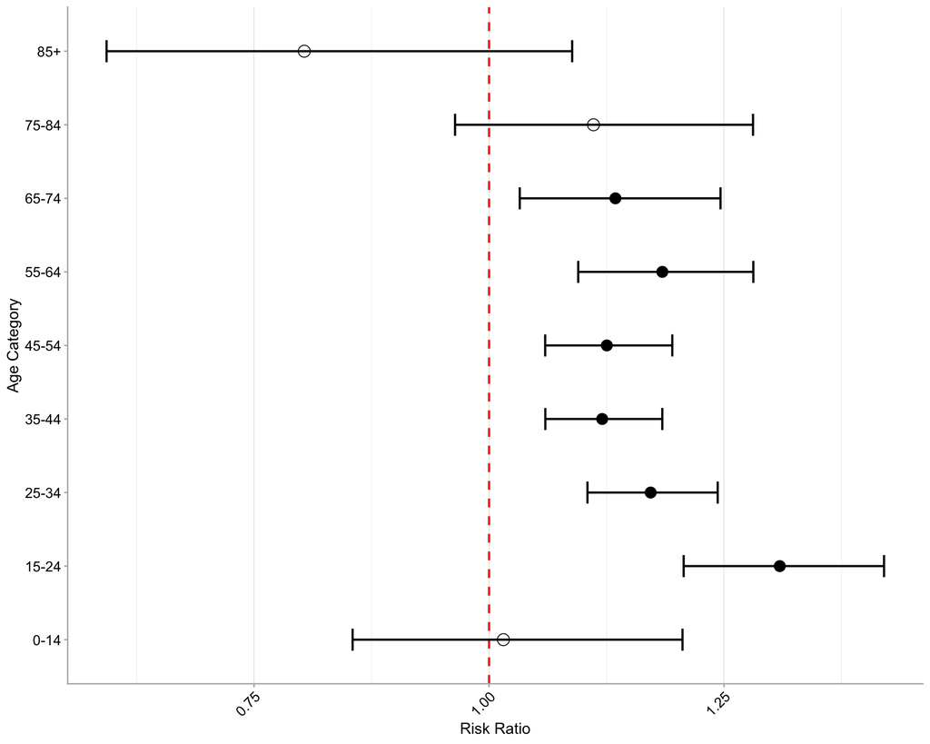

```r
desired_order <-
  c(
    "0-14",
    "15-24",
    "25-34",
    "35-44",
    "45-54",
    "55-64",
    "65-74",
    "75-84",
    "85+"
  )

rr_sex_by_age$Age_cat <- factor(rr_sex_by_age$Age_cat, levels = desired_order)

rr_sex_by_age_plot <- rr_sex_by_age %>%
  mutate(
    significant = ifelse(P_value < 0.05, "Significant", "Not Significant")
  ) %>%
  ggplot(aes(x = Age_cat, y = RR)) +
  geom_hline(yintercept = 1, linetype = "dashed", color = "red", size = 0.8) +
  geom_point(aes(shape = significant), color = "black", size = 4) +
  geom_errorbar(
    aes(ymin = Lower_CI, ymax = Upper_CI),
    color = "black",
    width = 0.3,
    linewidth = 0.8
  ) +
  scale_shape_manual(
    values = c("Significant" = 16, "Not Significant" = 1),
    guide = guide_legend(override.aes = list(size = 3))
  ) +
  coord_flip() +
  scale_x_discrete(
    labels = c(
      "0-14" = "0-14",
      "15-24" = "15-24",
      "25-34" = "25-34",
      "35-44" = "35-44",
      "45-54" = "45-54",
      "55-64" = "55-64",
      "65-74" = "65-74",
      "75-84" = "75-84",
      "85+" = "85+"
    )
  ) +
  labs(
    #title = "Female Risk Ratios by Age Group",
    #subtitle = "Reference: Males in same age group.",
    y = "Risk Ratio",
    x = "Age Category",
    shape = "Statistical Significance"
  ) +
  guides(
    shape = guide_legend(override.aes = list(color = "black"))
  ) +
  theme(
    legend.position = "none",
    panel.grid.major.y = element_blank()
  )

rr_sex_by_age_plot
```

```r
# Save plot
ggsave(
  "plots/risk_ratio_sex_by_age.png",
  rr_sex_by_age_plot,
  width = 12,
  height = 12,
  units = "cm",
  bg = "transparent"
)
```

# Risk Ratios for Age-Sex Combinations

Calculate risk ratios for each age-sex group relative to females aged 25-34 as the reference population, with Bonferroni correction for multiple comparisons.

```r
calc_combined_rr <- function(
  data,
  age_cat,
  sex,
  ref_age = "25-34",
  ref_sex = "F"
) {
  # Target group
  target_data <- data |>
    filter(Age_cat == age_cat, Sex == sex) |>
    count(Status) |>
    pivot_wider(names_from = Status, values_from = n, values_fill = 0)

  # Reference group
  ref_data <- data |>
    filter(Age_cat == ref_age, Sex == ref_sex) |>
    count(Status) |>
    pivot_wider(names_from = Status, values_from = n, values_fill = 0)

  # Correct matrix: rows = groups, cols = positive/negative
  rr_mat <- matrix(
    c(
      target_data$Positive,
      target_data$Negative,
      ref_data$Positive,
      ref_data$Negative
    ),
    nrow = 2,
    byrow = TRUE
  )

  rr_result <- riskratio(rr_mat, rev = "columns")

  tibble(
    Age_cat = age_cat,
    Sex = sex,
    RR = rr_result$measure[2, "estimate"],
    Lower_CI = rr_result$measure[2, "lower"],
    Upper_CI = rr_result$measure[2, "upper"],
    P_value = rr_result$p.value[2, "fisher.exact"]
  )
}
```

```r
# Calculate combined risk ratios using Male 25-34 as reference
age_sex_combinations <- expand_grid(
  Age_cat = unique(data_no_multi$Age_cat),
  Sex = c("M", "F")
) %>%
  filter(!(Age_cat == "25-34" & Sex == "F")) # Remove reference group

combined_rr_results <- map2_dfr(
  age_sex_combinations$Age_cat,
  age_sex_combinations$Sex,
  ~ calc_combined_rr(data_no_multi, .x, .y)
) |>
  mutate(
    # Bonferroni correction for 17 comparisons
    P_value_adj = p.adjust(P_value, method = "bonferroni"),
    significant_raw = P_value < 0.05,
    significant_adj = P_value_adj < 0.05
  )

print("Risk ratios using Females 25-34 as reference:")
print(combined_rr_results)

write.csv(
  combined_rr_results,
  "results/combined_rr_results.csv",
  row.names = FALSE
)
```

```
[1] "Risk ratios using Females 25-34 as reference:"
# A tibble: 17 × 9
   Age_cat Sex      RR Lower_CI Upper_CI  P_value P_value_adj significant_raw
   <chr>   <chr> <dbl>    <dbl>    <dbl>    <dbl>       <dbl> <lgl>
 1 35-44   M     0.573    0.491    0.669 2.22e-12    3.77e-11 TRUE
 2 35-44   F     0.766    0.661    0.887 3.58e- 4    6.08e- 3 TRUE
 3 25-34   M     0.608    0.514    0.719 1.43e- 8    2.43e- 7 TRUE
 4 45-54   M     0.484    0.419    0.559 4.15e-24    7.05e-23 TRUE
 5 45-54   F     0.606    0.528    0.696 1.68e-13    2.86e-12 TRUE
 6 55-64   M     0.366    0.320    0.419 7.91e-54    1.34e-52 TRUE
 7 55-64   F     0.447    0.392    0.509 1.57e-40    2.67e-39 TRUE
 8 15-24   M     0.466    0.396    0.549 2.96e-18    5.03e-17 TRUE
 9 15-24   F     0.878    0.743    1.04  1.34e- 1    1   e+ 0 FALSE
10 65-74   M     0.344    0.300    0.393 1.44e-58    2.46e-57 TRUE
11 65-74   F     0.388    0.341    0.442 6.14e-56    1.04e-54 TRUE
12 85+     M     0.627    0.391    1.00  7.71e- 2    1   e+ 0 FALSE
13 85+     F     0.427    0.307    0.593 5.07e- 5    8.62e- 4 TRUE
14 0-14    M     0.398    0.333    0.475 2.44e-19    4.15e-18 TRUE
15 0-14    F     0.405    0.334    0.490 1.06e-15    1.80e-14 TRUE
16 75-84   M     0.373    0.316    0.440 5.32e-26    9.04e-25 TRUE
17 75-84   F     0.420    0.358    0.493 1.69e-23    2.88e-22 TRUE
# ℹ 1 more variable: significant_adj <lgl>
```

## Forest Plot: Combined Age-Sex Risk Ratios

Create a forest plot showing risk ratios for all age-sex combinations relative to the reference group, colour-coded by sex and with significance indicators.

```r
MALE_COLOR <- "#0072B2"
FEMALE_COLOR <- "#D55E00"

plot_data <- combined_rr_results %>%
  mutate(
    # Create a combined label for better visualization
    group_label = paste0(Age_cat, " ", Sex),
    # Create significance indicator
    significant = ifelse(P_value < 0.05, "Significant", "Not Significant"),
    # Create proper ordering: first by age, then by sex within age
    Age_cat = factor(
      Age_cat,
      levels = c(
        "0-14",
        "15-24",
        "25-34",
        "35-44",
        "45-54",
        "55-64",
        "65-74",
        "75-84",
        "85+"
      )
    ),
    Sex = factor(Sex, levels = c("M", "F")),
    # Create ordered factor for y-axis that respects age then sex ordering
    group_label = factor(
      group_label,
      levels = expand_grid(
        Age_cat = c(
          "0-14",
          "15-24",
          "25-34",
          "35-44",
          "45-54",
          "55-64",
          "65-74",
          "75-84",
          "85+"
        ),
        Sex = c("M", "F")
      ) %>%
        filter(!(Age_cat == "25-34" & Sex == "F")) %>% # Remove reference
        mutate(label = paste(Age_cat, Sex)) %>%
        pull(label)
    )
  )
```

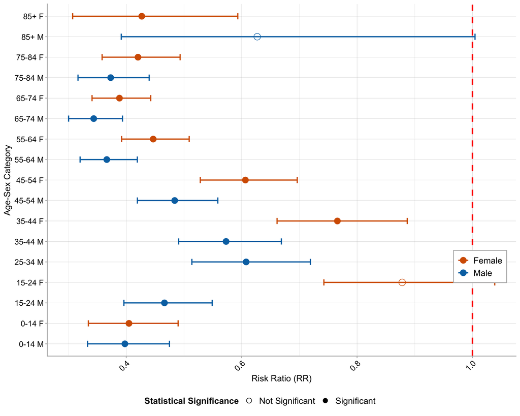

```r
plot_data <- plot_data %>%
  mutate(
    Sex_label = case_when(
      Sex == "M" ~ "Male",
      Sex == "F" ~ "Female"
    )
  )

combined_rr_results_plot <- plot_data %>%
  ggplot(aes(x = RR, y = group_label)) +
  geom_vline(xintercept = 1, linetype = "dashed", color = "red", size = 1) +
  geom_point(aes(color = Sex_label, shape = significant), size = 4) +
  geom_errorbarh(
    aes(xmin = Lower_CI, xmax = Upper_CI, color = Sex_label),
    height = 0.3,
    linewidth = 0.8
  ) +
  scale_color_manual(
    name = "Sex",
    values = c("Male" = MALE_COLOR, "Female" = FEMALE_COLOR)
  ) +
  scale_shape_manual(
    name = "Statistical Significance",
    values = c("Significant" = 16, "Not Significant" = 1),
    guide = guide_legend(override.aes = list(size = 3))
  ) +
  labs(
    #title = "Risk Ratios for Age-Sex Combinations",
    #subtitle = "Reference: Male 25-34 years",
    x = "Risk Ratio (RR)",
    y = "Age-Sex Category"
  ) +
  guides(
    color = guide_legend(
      override.aes = list(shape = 16),
      order = 1
    ),
    shape = guide_legend(
      override.aes = list(color = "black"),
      order = 2
    )
  ) +
  theme(
    legend.position = "bottom",
    legend.box = "vertical",
    legend.spacing = unit(0.5, "cm"),
    panel.grid.major.y = element_line(size = 0.1, colour = "grey70")
  )

# Extract the plot and legends
combined_rr_results_plot_final <- combined_rr_results_plot +
  theme(
    axis.title.y = element_text(hjust = 0.5, margin = margin(r = 8)),
    legend.position = c(0.98, 0.3),
    legend.justification = c("right", "top"),
    legend.text = element_text(size = 12),
    legend.background = element_rect(
      fill = "white",
      color = "grey70",
      linewidth = 0.5
    ),
    legend.margin = margin(5, 10, 5, 5),
    legend.box = "vertical"
  ) +
  guides(
    # Sex legend inside plot
    color = guide_legend(
      override.aes = list(shape = 16),
      title = NULL,
      order = 1
    ),
    # Significance legend at bottom - we'll handle this separately
    shape = "none"
  )

# Add the significance legend manually at the bottom
library(gridExtra)
library(grid)

# Create the significance legend separately
sig_legend <- data.frame(
  x = c(1, 2),
  y = c(1, 1),
  significant = c("Significant", "Not Significant")
)

sig_legend_plot <- ggplot(sig_legend, aes(x = x, y = y, shape = significant)) +
  geom_point(size = 4, color = "black") +
  scale_shape_manual(
    name = "Statistical Significance",
    values = c("Significant" = 16, "Not Significant" = 1)
  ) +
  theme_void() +
  theme(
    legend.text = element_text(size = 12),
    legend.title = element_text(size = 12, face = "bold"),
    legend.position = "bottom",
    legend.direction = "horizontal",
    legend.box = "horizontal",
    legend.background = element_rect(
      fill = "white",
      color = "white",
      linewidth = 0.5
    )
  ) +
  guides(shape = guide_legend(override.aes = list(size = 3)))

# Extract just the legend
sig_legend_grob <- cowplot::get_legend(sig_legend_plot)

# Combine plot with bottom legend
library(cowplot)

combined_rr_results_plot <- plot_grid(
  combined_rr_results_plot_final,
  sig_legend_grob,
  ncol = 1,
  rel_heights = c(1, 0.08)
)

combined_rr_results_plot
```

```r
# Save the plot
ggsave(
  "plots/combined_risk_ratios_age_sex.png",
  combined_rr_results_plot,
  width = 20,
  height = 10,
  units = "cm",
  bg = "transparent"
)
```

# Risk Ratios by Age Group

```r
# Create age data
age_data <- age_by_sex_data %>%
  dplyr::select(Age_cat, Total, Positive, Positive_pct)
```

```r
calc_rr_age_vs_ref <- function(df, age_cat, ref_cat = "25-34") {
  # Get row for target age group
  group_df <- df %>% filter(Age_cat == age_cat)
  pos_group <- group_df$Positive
  neg_group <- group_df$Total - pos_group

  # Get row for reference age group
  ref_df <- df %>% filter(Age_cat == ref_cat)
  pos_ref <- ref_df$Positive
  neg_ref <- ref_df$Total - pos_ref

  # Construct 2x2 matrix: rows = group, ref; cols = positive, negative
  rr_mat <- matrix(
    c(pos_group, neg_group, pos_ref, neg_ref),
    nrow = 2,
    byrow = TRUE,
    dimnames = list(
      Group = c(age_cat, ref_cat),
      Status = c("Positive", "Negative")
    )
  )

  # Calculate risk ratio
  rr <- suppressWarnings(riskratio(rr_mat, rev = "columns"))

  # Extract RR for comparison row
  tibble(
    Age_cat = age_cat,
    RR = rr$measure[2, "estimate"],
    Lower_CI = rr$measure[2, "lower"],
    Upper_CI = rr$measure[2, "upper"],
    P_value = rr$p.value[2, "fisher.exact"]
  )
}
```

```r
# Calculate for each age group vs 25-34
rr_age <- bind_rows(
  calc_rr_age_vs_ref(age_data, "0-14"),
  calc_rr_age_vs_ref(age_data, "15-24"),
  calc_rr_age_vs_ref(age_data, "45-54"),
  calc_rr_age_vs_ref(age_data, "55-64"),
  calc_rr_age_vs_ref(age_data, "65-74"),
  calc_rr_age_vs_ref(age_data, "75-84"),
  calc_rr_age_vs_ref(age_data, "85+")
)

print(rr_age)
```

```
# A tibble: 7 × 5
  Age_cat    RR Lower_CI Upper_CI  P_value
  <chr>   <dbl>    <dbl>    <dbl>    <dbl>
1 0-14    0.487    0.427    0.555 1.95e-22
2 15-24   0.837    0.742    0.943 3.73e- 3
3 45-54   0.676    0.611    0.748 4.43e-15
4 55-64   0.505    0.459    0.555 1.70e-52
5 65-74   0.451    0.410    0.496 3.43e-71
6 75-84   0.485    0.432    0.545 4.30e-31
7 85+     0.606    0.461    0.796 1.83e- 3
```

## Forest Plot: Age-Stratified Risk Ratios

Create a horizontal forest plot showing age-group risk ratios with 95% confidence intervals and significance markers.

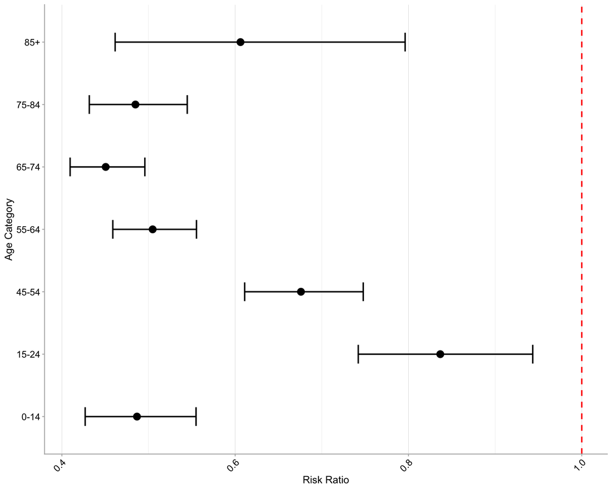

```r
# Plot
rr_age_plot <- rr_age %>%
  mutate(
    significant = ifelse(P_value < 0.05, "Significant", "Not Significant")
  ) %>%
  ggplot(aes(x = Age_cat, y = RR)) +
  geom_hline(yintercept = 1, linetype = "dashed", color = "red", size = 0.8) +
  geom_point(aes(shape = significant), color = "black", size = 4) +
  geom_errorbar(
    aes(ymin = Lower_CI, ymax = Upper_CI),
    color = "black",
    width = 0.3,
    linewidth = 0.8
  ) +
  scale_shape_manual(
    values = c("Significant" = 16, "Not Significant" = 1),
    guide = guide_legend(override.aes = list(size = 3))
  ) +
  coord_flip() +
  labs(
    #title = "Risk Ratios of Positivity by Age Group",
    #subtitle = "Reference: 25-34 age group.",
    y = "Risk Ratio",
    x = "Age Category",
    shape = "Statistical Significance"
  ) +
  guides(
    shape = guide_legend(override.aes = list(color = "black"))
  ) +
  theme(
    legend.position = "none",
    panel.grid.major.y = element_blank()
  )

rr_age_plot
```

```r
ggsave(
  "plots/risk_ratio_age_vs_ref_group_25-34.png",
  rr_age_plot,
  width = 12,
  height = 12,
  units = "cm",
  bg = "transparent"
)
```

# Combined Risk Ratio Figure

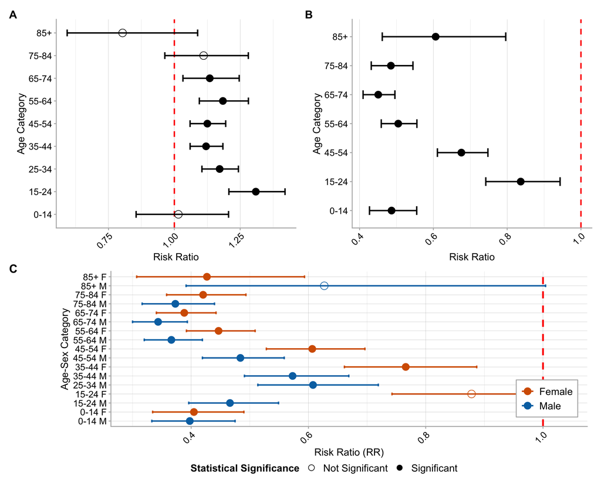

```r
combined_rr_plots <-
  ((rr_sex_by_age_plot + rr_age_plot) / combined_rr_results_plot) +
  #plot_layout(ncol = 2) +
  plot_annotation(tag_level = 'A') &
  theme(plot.tag = element_text(face = "bold"))

combined_rr_plots
```

```r
ggsave(
  "plots/Final_Plots/Fig_S1_risk_ratios.png",
  combined_rr_plots,
  width = 24,
  height = 20,
  units = "cm",
  bg = "white",
  dpi = 300
)
```

# Mantel-Haenszel Test

Perform the Cochran-Mantel-Haenszel test for conditional independence to assess whether the sex-positivity association is consistent across age strata.

```r
# Create stratified analysis - convert to 3D array
mh_data <- data_no_multi %>%
  count(Age_cat, Sex, Status) %>%
  pivot_wider(names_from = Status, values_from = n, values_fill = 0)

# Create a 3D array: [Sex, Status, Age_cat]
# Dimensions: 2 (M/F) x 2 (Positive/Negative) x 8 (age groups)
mh_array <- array(
  dim = c(2, 2, length(unique(mh_data$Age_cat))),
  dimnames = list(
    Sex = c("F", "M"),
    Status = c("Positive", "Negative"),
    Age_cat = sort(unique(mh_data$Age_cat))
  )
)

# Fill the array
for (i in seq_along(unique(mh_data$Age_cat))) {
  age_group <- sort(unique(mh_data$Age_cat))[i]
  age_data <- mh_data %>% filter(Age_cat == age_group)

  # Female counts
  mh_array["F", "Positive", i] <- age_data$Positive[age_data$Sex == "F"]
  mh_array["F", "Negative", i] <- age_data$Negative[age_data$Sex == "F"]

  # Male counts
  mh_array["M", "Positive", i] <- age_data$Positive[age_data$Sex == "M"]
  mh_array["M", "Negative", i] <- age_data$Negative[age_data$Sex == "M"]
}

# Perform Mantel-Haenszel test
mh_result <- mantelhaen.test(mh_array)
print(mh_result)
```

```
    Mantel-Haenszel chi-squared test with continuity correction

data:  mh_array
Mantel-Haenszel X-squared = 114.22, df = 1, p-value < 2.2e-16
alternative hypothesis: true common odds ratio is not equal to 1
95 percent confidence interval:
 0.6251468 0.7235325
sample estimates:
common odds ratio
        0.6725429
```